# Actividad2:Estimación del modelo lineal

María Sánchez Paniagua

2024-03-17

# Ejercicios del libro de Faraway

## 1. (Ejercicio 1 cap. 2 pág. 30)

The dataset teengamb concerns a study of teenage gambling in Britain. Fit a regression model with the expenditure on gambling as the response and the sex, status, income and verbal score as predictors. Present the output.

```r
library(faraway)
data(teengamb)
modelo <- lm(gamble ~ sex + status + income + verbal, data = teengamb)
modelo
```

```
##
## Call:
## lm(formula = gamble ~ sex + status + income + verbal, data = teengamb)
##
## Coefficients:
## (Intercept)          sex       status       income       verbal
##    22.55565    -22.11833      0.05223      4.96198     -2.95949
```

```r
summary(modelo)
```

```
##
## Call:
## lm(formula = gamble ~ sex + status + income + verbal, data = teengamb)
##
## Residuals:
##     Min      1Q  Median      3Q     Max
## -51.082 -11.320  -1.451   9.452  94.252
##
## Coefficients:
##              Estimate Std. Error t value Pr(>|t|)
## (Intercept)  22.55565   17.19680   1.312   0.1968
## sex         -22.11833    8.21111  -2.694   0.0101 *
## status        0.05223    0.28111   0.186   0.8535
## income        4.96198    1.02539   4.839 1.79e-05 ***
## verbal       -2.95949    2.17215  -1.362   0.1803
## ---
## Signif. codes:  0 '***' 0.001 '**' 0.01 '*' 0.05 '.' 0.1 ' ' 1
##
## Residual standard error: 22.69 on 42 degrees of freedom
## Multiple R-squared:  0.5267, Adjusted R-squared:  0.4816
## F-statistic: 11.69 on 4 and 42 DF,  p-value: 1.815e-06
```

1. What percentage of variation in the response is explained by these predictors?

```r
R_cuadrado <- summary(modelo)$r.squared * 100
cat("Porcentaje de variación explicada", round(R_cuadrado), "%\n")
```

```
## Porcentaje de variación explicada 53 %
```

2. Which observation has the largest (positive) residual? Give the case number.

```r
residuos <-residuals(modelo)
cat("El mayor residuo es ", which.max(residuos), "\n")
```

```
## El mayor residuo es  24
```

3. Compute the mean and median of the residuals.

```r
media_residuos <- mean(residuals(modelo))
mediana_residuos <- median(residuals(modelo))
```

La media de los residuos es -1.5569143^{-16} y la mediana -1.4513921

4. Compute the correlation of the residuals with the fitted values.

```r
corr<- cor(residuals(modelo), fitted(modelo))
```

La correlación de los residuos con los valores ajustados: -6.2158235^{-17}

5. Compute the correlation of the residuals with the income.

```r
corr <- cor(residuals(modelo), teengamb$income)
```

La correlación de los residuos con el ingreso: 3.2470578^{-17}

6. For all other predictors held constant, what would be the difference in predicted expenditure on gambling for a male compared to a female?

```r
modelo <- lm(gamble ~ sex + status + income + verbal, data = teengamb)
coeficientes <- coef(modelo)
coeficientes
```

```
##  (Intercept)          sex       status       income       verbal
##  22.55565063 -22.11833009   0.05223384   4.96197922  -2.95949350
```

```r
diferencia_prediccion <- abs(coeficientes["sex"])
```

Diferencia en el gasto predicho para hombres vs. mujeres: 22.1183301.

## 2. (Ejercicio 2 cap. 2 pág. 30)

The dataset uswages is drawn as a sample from the Current Population Survey in 1988. Fit a model with weekly wages as the response and years of education and experience as predictors. Report and give a simple interpretation to the regression coefficient for years of education. Now fit the same model but with logged weekly wages. Give an interpretation to the regression coefficient for years of education. Which interpretation is more natural?

```r
data(uswages)
modelo1 <- lm(wage ~ educ + exper, data = uswages)
summary(modelo1)
```

```
##
## Call:
## lm(formula = wage ~ educ + exper, data = uswages)
##
## Residuals:
##     Min      1Q  Median      3Q     Max
## -1018.2  -237.9   -50.9   149.9  7228.6
##
## Coefficients:
##              Estimate Std. Error t value Pr(>|t|)
## (Intercept) -242.7994    50.6816  -4.791 1.78e-06 ***
## educ          51.1753     3.3419  15.313  < 2e-16 ***
## exper          9.7748     0.7506  13.023  < 2e-16 ***
## ---
## Signif. codes:  0 '***' 0.001 '**' 0.01 '*' 0.05 '.' 0.1 ' ' 1
##
## Residual standard error: 427.9 on 1997 degrees of freedom
## Multiple R-squared:  0.1351, Adjusted R-squared:  0.1343
## F-statistic:   156 on 2 and 1997 DF,  p-value: < 2.2e-16
```

El salario semanal aumenta en promedio en $51.1753 por cada año de educación

Segunda interpretacion:

```r
modelo2 <- lm(log(wage) ~ educ + exper, data = uswages)
summary(modelo2)
```

```
##
## Call:
## lm(formula = log(wage) ~ educ + exper, data = uswages)
##
## Residuals:
##     Min      1Q  Median      3Q     Max
## -2.7533 -0.3495  0.1068  0.4381  3.5699
##
## Coefficients:
##             Estimate Std. Error t value Pr(>|t|)
## (Intercept) 4.650319   0.078354   59.35   <2e-16 ***
## educ        0.090506   0.005167   17.52   <2e-16 ***
## exper       0.018079   0.001160   15.58   <2e-16 ***
## ---
## Signif. codes:  0 '***' 0.001 '**' 0.01 '*' 0.05 '.' 0.1 ' ' 1
##
## Residual standard error: 0.6615 on 1997 degrees of freedom
## Multiple R-squared:  0.1749, Adjusted R-squared:  0.174
## F-statistic: 211.6 on 2 and 1997 DF,  p-value: < 2.2e-16
```

Se espera que un año adicional de educación esté asociado con un aumento del 9.05 en el salario semanal.

## 4. (Ejercicio 4 cap. 2 pág. 30)

The dataset prostate comes from a study on 97 men with prostate cancer who were due to receive a radical prostatectomy.

Fit a model with lpsa as the response and lcavol as the predictor. Record the residual standard error and the R2.

```r
data(prostate)
modelo_1 <- lm(lpsa ~ lcavol, data = prostate)
summary(modelo_1)
```

```
##
## Call:
## lm(formula = lpsa ~ lcavol, data = prostate)
##
## Residuals:
##      Min       1Q   Median       3Q      Max
## -1.67625 -0.41648  0.09859  0.50709  1.89673
##
## Coefficients:
##             Estimate Std. Error t value Pr(>|t|)
## (Intercept)  1.50730    0.12194   12.36   <2e-16 ***
## lcavol       0.71932    0.06819   10.55   <2e-16 ***
## ---
## Signif. codes:  0 '***' 0.001 '**' 0.01 '*' 0.05 '.' 0.1 ' ' 1
##
## Residual standard error: 0.7875 on 95 degrees of freedom
## Multiple R-squared:  0.5394, Adjusted R-squared:  0.5346
## F-statistic: 111.3 on 1 and 95 DF,  p-value: < 2.2e-16
```

```r
# Error estándar residual y el R2 del modelo inicial
error_residual <- summary(modelo_1)$sigma
r_cuadrado <- summary(modelo_1)$r.squared

# Guardo los resultados en un dataframe al que iré añadiendo las variables de cada modelo
resultados_df <- data.frame(variable = "lcavol", error_residual = error_residual, r_cuadrado = r_cuadrado)
```

Now add lweight, svi, lbph, age, lcp, pgg45 and gleason to the model one at a time. For each model record the residual standard error and the R2.

```r
variables <- c("lweight", "svi", "lbph", "age", "lcp", "pgg45", "gleason")

# Ajustar los modelos y registrar los resultados en el df por cada variable
for (variable in variables) {
  modelo_x <- lm(paste("lpsa ~ lcavol +", variable), data = prostate)
  error_residual <- summary(modelo_x)$sigma
  r_cuadrado <- summary(modelo_x)$r.squared
  resultados_df <- rbind(resultados_df, data.frame(variable = variable, error_residual = error_residual, r_cuadrado = r_cuadrado))
}

resultados_df
```

```
##   variable error_residual r_cuadrado
## 1   lcavol      0.7874994  0.5394319
## 2  lweight      0.7506469  0.5859345
## 3      svi      0.7556684  0.5803761
## 4     lbph      0.7694222  0.5649622
## 5      age      0.7916601  0.5394517
## 6      lcp      0.7872559  0.5445618
## 7    pgg45      0.7801855  0.5527057
## 8  gleason      0.7888801  0.5426807
```

Plot the trends in these two statistics:

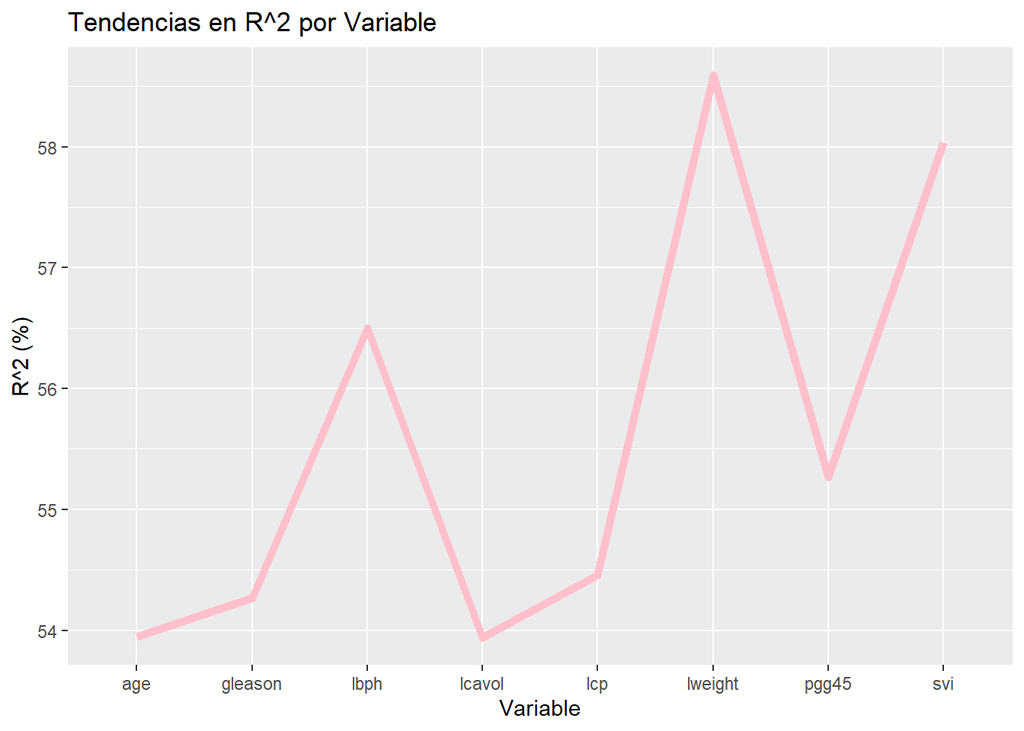

```r
library(ggplot2)
ggplot(resultados_df, aes(x = variable)) +
  geom_line(aes(y = r_cuadrado * 100, group = 1), color = "pink", size = 2) +
  labs(x = "Variable", y = "R^2 (%)", title = "Tendencias en R^2 por Variable")
```

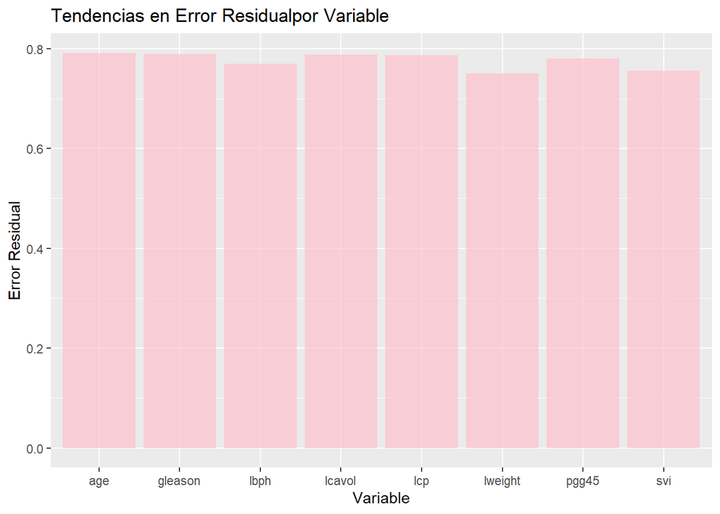

```r
ggplot(resultados_df, aes(x = variable)) +
  geom_bar(aes(y = error_residual), stat = "identity", fill = "pink", alpha = 0.7) +
  labs(x = "Variable", y = "Error Residual", title = "Tendencias en Error Residualpor Variable")
```

## 5. (Ejercicio 5 cap. 2 pág. 30)

Using the prostate data, plot lpsa against lcavol.

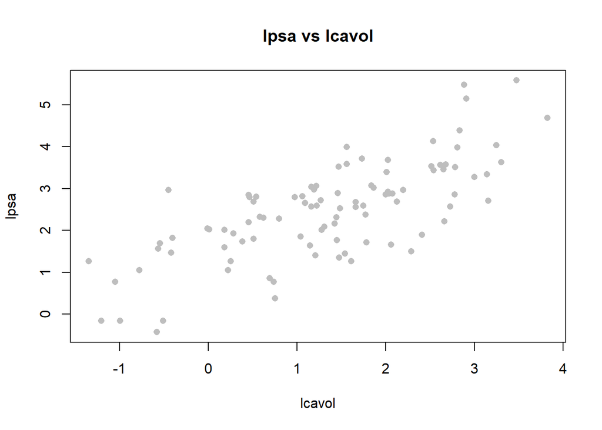

```r
data(prostate)

# Dispersión de lpsa en lcavol
plot(prostate$lcavol, prostate$lpsa, xlab = "lcavol", ylab = "lpsa", main = "lpsa vs lcavol", col = "grey", pch = 16)
```

Fit the regressions of lpsa on lcavol and lcavol on lpsa. Display both regression lines on the plot. At what point do the two lines intersect?

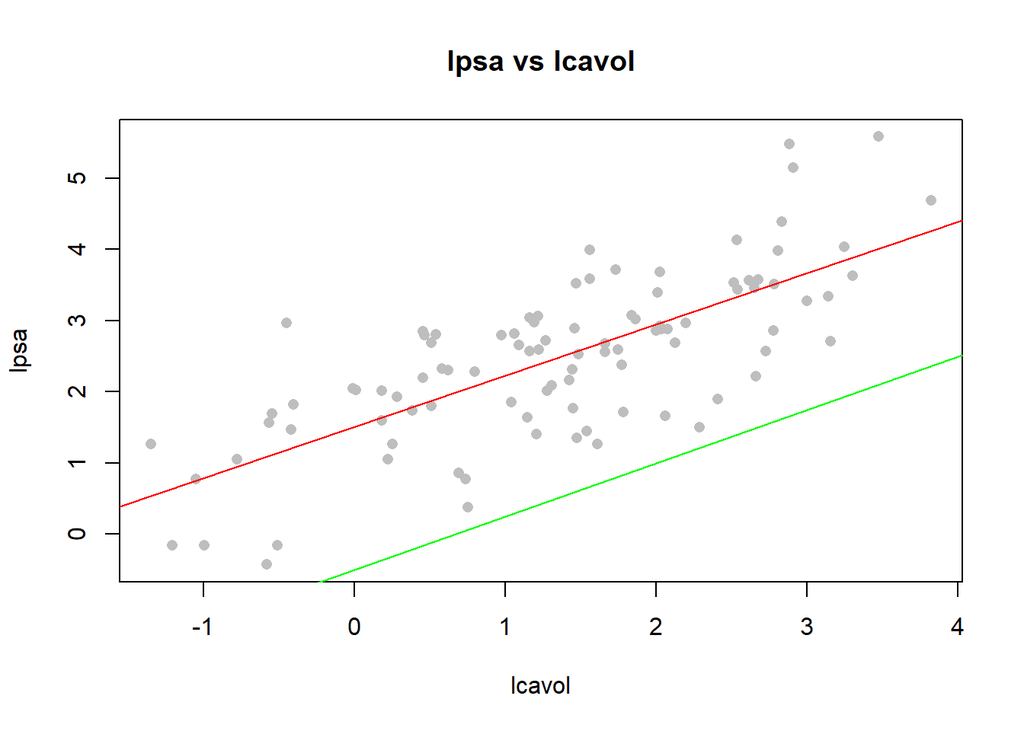

```r
plot(prostate$lcavol, prostate$lpsa, xlab = "lcavol", ylab = "lpsa", main = "lpsa vs lcavol", col = "grey", pch = 16)

# Regresión de lpsa en lcavol
modelo_lpsa_lcavol <- lm(lpsa ~ lcavol, data = prostate)
abline(modelo_lpsa_lcavol, col = "red")

# Regresión de lcavol en lpsa
modelo_lcavol_lpsa <- lm(lcavol ~ lpsa, data = prostate)
abline(modelo_lcavol_lpsa, col = "green")
```

```r
# Calculamos el punto de intersección de las dos rectas
m1 <- coef(modelo_lpsa_lcavol)["lcavol"]
c1 <- coef(modelo_lpsa_lcavol)["(Intercept)"]
m2 <- coef(modelo_lcavol_lpsa)["lpsa"]
c2 <- coef(modelo_lcavol_lpsa)["(Intercept)"]


# Calcular el punto de intersección
lcavol_interseccion <- (c2 - c1) / (m1 - m2)
lpsa_interseccion <- m1 * lcavol_interseccion + c1


cat("Punto de intersección: (lcavol =", lcavol_interseccion, ", lpsa =", lpsa_interseccion, ")")
```

```
## Punto de intersección: (lcavol = 65.88061 , lpsa = 48.89655 )
```

Grafico la intersección:

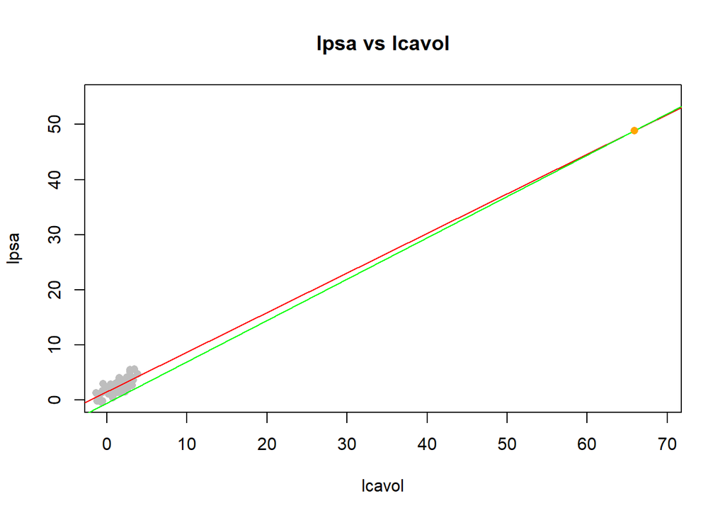

```r
plot(prostate$lcavol, prostate$lpsa, xlab = "lcavol", ylab = "lpsa", main = "lpsa vs lcavol", col = "grey", pch = 16,  ylim = c(0,55), xlim = c(0,69))

# Ajustar la regresión de lpsa en lcavol
modelo_lpsa_lcavol <- lm(lpsa ~ lcavol, data = prostate)
abline(modelo_lpsa_lcavol, col = "red")

# Ajustar la regresión de lcavol en lpsa
modelo_lcavol_lpsa <- lm(lcavol ~ lpsa, data = prostate)
abline(modelo_lcavol_lpsa, col = "green")

# Agregar el punto de intersección
points(lcavol_interseccion, lpsa_interseccion, col = "orange", pch = 16)
```

## 6. (Ejercicio 6 cap. 2 pág. 30)

Thirty samples of cheddar cheese were analyzed for their content of acetic acid, hydrogen sulfide and lactic acid. Each sample was tasted and scored by a panel of judges and the average taste score produced. Use the cheddar data to answer the following:

1. Fit a regression model with taste as the response and the three chemical contents as predictors. Report the values of the regression coefficients.

```r
data(cheddar)
modelo <- lm(taste ~ Acetic + H2S + Lactic, data = cheddar)

# Valores de los coeficientes de regresión
coeficientes <- coef(modelo)
print(coeficientes)
```

```
## (Intercept)      Acetic         H2S      Lactic
## -28.8767696   0.3277413   3.9118411  19.6705434
```

2. Compute the correlation between the fitted values and the response. Square it. Identify where this value appears in the regression output.

```r
cor_fitted_response <- cor(predict(modelo), cheddar$taste)
cor_sq <- cor_fitted_response^2
print(cor_sq)
```

```
## [1] 0.6517747
```

```r
summary(modelo)
```

```
##
## Call:
## lm(formula = taste ~ Acetic + H2S + Lactic, data = cheddar)
##
## Residuals:
##     Min      1Q  Median      3Q     Max
## -17.390  -6.612  -1.009   4.908  25.449
##
## Coefficients:
##             Estimate Std. Error t value Pr(>|t|)
## (Intercept) -28.8768    19.7354  -1.463  0.15540
## Acetic        0.3277     4.4598   0.073  0.94198
## H2S           3.9118     1.2484   3.133  0.00425 **
## Lactic       19.6705     8.6291   2.280  0.03108 *
## ---
## Signif. codes:  0 '***' 0.001 '**' 0.01 '*' 0.05 '.' 0.1 ' ' 1
##
## Residual standard error: 10.13 on 26 degrees of freedom
## Multiple R-squared:  0.6518, Adjusted R-squared:  0.6116
## F-statistic: 16.22 on 3 and 26 DF,  p-value: 3.81e-06
```

Este valor aparece como “Multiple R squared”

3. Fit the same regression model but without an intercept term. What is the value of R2 reported in the output? Compute a more reasonable measure of the good- ness of fit for this example.

```r
modelo_si <- lm(taste ~ Acetic +H2S + Lactic - 1, data = cheddar)
r2_si <- summary(modelo_si)$r.squared
cat("EL valor de R cuadrado sin intercepto es", r2_si, "\n")
```

```
## EL valor de R cuadrado sin intercepto es 0.8877059
```

```r
# Calcular una medida de la bondad del ajuste --> R cuadrado ajustado
r_cuadrado_ajustado <- summary(modelo_si)$adj.r.squared

cat("EL valor de R cuadrado  es", r_cuadrado_ajustado, "\n")
```

```
## EL valor de R cuadrado  es 0.8752288
```

4. Compute the regression coefficients from the original fit using the QR decomposition showing your R code.

```r
X <- model.matrix(modelo)
qr_decomp <- qr(X)
y <- cheddar$taste

# Resolver el sistema utilizando la función 'qr.coef' que aplica la descomposición QR para resolver el sistema
coeficientes_qr <- qr.coef(qr_decomp, y)


print(coeficientes_qr)
```

```
## (Intercept)      Acetic         H2S      Lactic
## -28.8767696   0.3277413   3.9118411  19.6705434
```

## 7. (Ejercicio 7 cap. 2 pág. 31)

An experiment was conducted to determine the effect of four factors on the resistivity of a semiconductor wafer. The data is found in wafer where each of the four factors is coded as − or + depending on whether the low or the high setting for that factor was used. Fit the linear model resist ~ x1 + x2 + x3 + x4.

```r
data(wafer)
modelo <- lm(resist ~ x1 + x2 + x3 + x4, data = wafer)
```

1. Extract the X matrix using the model.matrix function. Examine this to determine how the low and high levels have been coded in the model.

```r
X <- model.matrix(modelo)
X
```

```
##    (Intercept) x1+ x2+ x3+ x4+
## 1            1   0   0   0   0
## 2            1   1   0   0   0
## 3            1   0   1   0   0
## 4            1   1   1   0   0
## 5            1   0   0   1   0
## 6            1   1   0   1   0
## 7            1   0   1   1   0
## 8            1   1   1   1   0
## 9            1   0   0   0   1
## 10           1   1   0   0   1
## 11           1   0   1   0   1
## 12           1   1   1   0   1
## 13           1   0   0   1   1
## 14           1   1   0   1   1
## 15           1   0   1   1   1
## 16           1   1   1   1   1
## attr(,"assign")
## [1] 0 1 2 3 4
## attr(,"contrasts")
## attr(,"contrasts")$x1
## [1] "contr.treatment"
##
## attr(,"contrasts")$x2
## [1] "contr.treatment"
##
## attr(,"contrasts")$x3
## [1] "contr.treatment"
##
## attr(,"contrasts")$x4
## [1] "contr.treatment"
```

2. Compute the correlation in the X matrix. Why are there some missing values in the matrix?

```r
correlation_X <- cor(X)
correlation_X
```

```
##             (Intercept) x1+ x2+ x3+ x4+
## (Intercept)           1  NA  NA  NA  NA
## x1+                  NA   1   0   0   0
## x2+                  NA   0   1   0   0
## x3+                  NA   0   0   1   0
## x4+                  NA   0   0   0   1
```

Hay valores missing porque está incluyendo el intercepto que es constante

3. What difference in resistance is expected when moving from the low to the high level of x1?

```r
coeficientes <- coef(modelo)
diferencia_resistencia_x1 <- coeficientes["x1+"]
print(diferencia_resistencia_x1)
```

```
##     x1+
## 25.7625
```

4. Refit the model without x4 and examine the regression coefficients and standard errors? What stayed the the same as the original fit and what changed?

```r
modelo_sin_x4 <- lm(resist ~ x1 + x2 + x3, data = wafer)
summary(modelo_sin_x4)
```

```
##
## Call:
## lm(formula = resist ~ x1 + x2 + x3, data = wafer)
##
## Residuals:
##     Min      1Q  Median      3Q     Max
## -36.137 -20.550   3.575  18.463  41.012
##
## Coefficients:
##             Estimate Std. Error t value Pr(>|t|)
## (Intercept)   229.54      13.32  17.231 7.88e-10 ***
## x1+            25.76      13.32   1.934 0.077047 .
## x2+           -69.89      13.32  -5.246 0.000206 ***
## x3+            43.59      13.32   3.272 0.006677 **
## ---
## Signif. codes:  0 '***' 0.001 '**' 0.01 '*' 0.05 '.' 0.1 ' ' 1
##
## Residual standard error: 26.64 on 12 degrees of freedom
## Multiple R-squared:  0.7777, Adjusted R-squared:  0.7221
## F-statistic: 13.99 on 3 and 12 DF,  p-value: 0.0003187
```

```r
summary(modelo)
```

```
##
## Call:
## lm(formula = resist ~ x1 + x2 + x3 + x4, data = wafer)
##
## Residuals:
##     Min      1Q  Median      3Q     Max
## -43.381 -17.119   4.825  16.644  33.769
##
## Coefficients:
##             Estimate Std. Error t value Pr(>|t|)
## (Intercept)   236.78      14.77  16.032 5.65e-09 ***
## x1+            25.76      13.21   1.950 0.077085 .
## x2+           -69.89      13.21  -5.291 0.000256 ***
## x3+            43.59      13.21   3.300 0.007083 **
## x4+           -14.49      13.21  -1.097 0.296193
## ---
## Signif. codes:  0 '***' 0.001 '**' 0.01 '*' 0.05 '.' 0.1 ' ' 1
##
## Residual standard error: 26.42 on 11 degrees of freedom
## Multiple R-squared:  0.7996, Adjusted R-squared:  0.7267
## F-statistic: 10.97 on 4 and 11 DF,  p-value: 0.0007815
```

Los que cambió fue el intercepto, los valores de R cuadrado y el error estándar residual. No cambiaron los coeficientes de las variables restantes.

5. Explain how the change in the regression coefficients is related to the correlation matrix of X.

# Ejercicios del libro de Carmona

## 1. (Ejercicio 2.1 del Capítulo 2 página 41)

1. Sí es lineal porque los estimadores tienen una relaión lineal con las variables. La matriz de diseño es:

```r
X <-matrix(c(1., 1., 0, 1., 2., 3.,1., 3., 8.), nrow = 3, byrow = TRUE)
X
```

```
##      [,1] [,2] [,3]
## [1,]    1    1    0
## [2,]    1    2    3
## [3,]    1    3    8
```

2. No es lineal porque los estimadores no tienen una relación lineal con las variables

c)No es lineal porque los estimadores no tienen una relación lineal con las variables

## 2. (Ejercicio 2.4 del Capítulo 2 página 42)

Hallar las estimaciones de cada bi y de la varianza del error.

```r
# Crear la matriz de diseño X y el vector de respuesta y
X <- matrix(c(1, 1, 1, 1,
              1, -1, 1, 1,
              1, 0, 0, 1,
              1, 0, 0, -1,
              1, 0, 1, 1,
              1, 1, -1, 1),
            nrow = 6, byrow = TRUE)
y <- c(9.2, 8.3, 5.4, -1.6, 8.7, 3.5)

# Creo el modelo sin interceptoo y obtengo coeficientes y varianza
modelo <- lm(y ~ X - 1)
estimaciones <- coef(modelo)
varianza_error <- summary(modelo)$sigma^2
print(estimaciones)
```

```
##        X1        X2        X3        X4
## 2.0685714 0.5342857 2.9400000 3.6685714
```

```r
print(varianza_error)
```

```
## [1] 0.08371429
```